# Practical 2 — From clusters to conclusions

BINF90004 Bioinformatics Case Studies · scRNA-seq

In Practical 1 we identified 19 clusters. We still need to make sense of these clusters – by giving them cell type labels. We then use the labelled, or annotated, clusters to make two biological claims: *which cell types change in abundance as the heart matures*, and *which genes change within a cell type*.

```r
library(Seurat)
library(ggplot2)
library(dplyr)
library(tidyr)
library(patchwork)
library(speckle)
library(edgeR)
library(limma)

options(future.globals.maxSize = 8 * 1024^3)

# Resolve the data folder whether you knit from practicals/ or run
# interactively with the repo root as your working directory. The third
# branch is the instructor's private authoring folder.
DATA <- if (dir.exists("data")) "data" else
        if (dir.exists("../data")) "../data" else "../dist"
```

```r
group_cols <- c(fetal = "#4E79A7", young = "#F28E2B", adult = "#59A14F")
```

```r
seu <- readRDS(file.path(DATA, "checkpoints/02_integrated_clustered.rds"))
seu
```

```
## An object of class Seurat
## 36424 features across 6982 samples within 2 assays
## Active assay: SCT (17471 features, 3000 variable features)
##  2 layers present: counts, data
##  1 other assay present: RNA
##  3 dimensional reductions calculated: pca, harmony, umap
```

```r
table(seu$seurat_clusters)
```

```
##
##    0    1    2    3    4    5    6    7    8    9   10   11   12   13   14   15
## 1775  867  761  506  503  415  346  322  266  223  166  162  161  127  116   96
##   16   17   18
##   86   53   31
```

# 1. Marker genes

A cluster is defined by the genes that are higher in it than in everything else. `FindAllMarkers()` runs that comparison for every cluster.

**We are loading a cached result rather than computing it.** Seurat’s default Wilcoxon implementation takes several minutes on 19 clusters, and there is no teaching value in watching a progress bar. The exact call that produced the cache is in the chunk below — run it later if you want.

```r
markers <- readRDS(file.path(DATA, "markers_cache.rds"))

# How it was produced:
# seu <- PrepSCTFindMarkers(seu)
# markers <- FindAllMarkers(seu, only.pos = TRUE,
#                           min.pct = 0.25, logfc.threshold = 0.5)

nrow(markers)
```

```
## [1] 19458
```

```r
head(markers)
```

|  | p_val | avg_log2FC | pct.1 | pct.2 | p_val_adj | cluster | gene |
| --- | --- | --- | --- | --- | --- | --- | --- |
| MYL4 | 0 | 2.008028 | 0.958 | 0.296 | 0 | 0 | MYL4 |
| STRIP2 | 0 | 2.301104 | 0.894 | 0.249 | 0 | 0 | STRIP2 |
| FSD2 | 0 | 2.229087 | 0.944 | 0.316 | 0 | 0 | FSD2 |
| BMP5 | 0 | 1.766206 | 0.931 | 0.306 | 0 | 0 | BMP5 |
| STARD4-AS1 | 0 | 2.277526 | 0.923 | 0.311 | 0 | 0 | STARD4-AS1 |
| PLEKHG4B | 0 | 2.164499 | 0.791 | 0.185 | 0 | 0 | PLEKHG4B |

```r
top5 <- markers |>
    group_by(cluster) |>
    slice_max(avg_log2FC, n = 5) |>
    summarise(top_genes = paste(gene, collapse = ", "))
top5
```

| cluster | top_genes |
| --- | --- |
| 0 | CUX2, GPR39, LINC02008, RNF175, BANCR |
| 1 | ADH1B, VIT, CATSPERB, AOX1, PLA2G2A |
| 2 | LINC01880, UGT2B4, APOB, TMEM178B, MYOM3 |
| 3 | FHL5, AGAP2, EGFLAM, LINC02237, FAM162B |
| 4 | GDF6, DSC3, LINC01133, DCC, DLK1 |
| 5 | NOTCH4, BTNL9, NR5A2, CYYR1, CYYR1-AS1 |
| 6 | MARCO, F13A1, CD163, MS4A14, SIGLEC1 |
| 7 | TROAP, PBK, KIF18B, BUB1, TTK |
| 8 | CSMD1, OPCML, BRINP3, ZMAT4, BRINP2 |
| 9 | HLA-DPA1, HLA-DQB1, HLA-DRA, HLA-DRB5, C1QA |

[output cut: 9 more lines]

## 1.1 Canonical markers

Published markers for the major cardiac populations (Sim et al. 2021 and standard references). Dot size is the fraction of nuclei expressing the gene; colour is mean expression.

```r
panel <- list(
    Cardiomyocyte  = c("TNNT2", "ACTN2", "TNNI3", "RYR2", "MYH6", "TTN"),
    Fibroblast     = c("COL1A1", "COL3A1", "DCN", "PDGFRA"),
    Endothelial    = c("PECAM1", "CDH5", "VWF", "FLT1"),
    Immune         = c("PTPRC", "CD68", "CD163", "CD74"),
    Epicardial     = c("UPK3B", "WT1", "MSLN"),
    Neural         = c("PLP1", "S100B", "NRXN1"),
    `Smooth muscle`= c("MYH11", "TAGLN", "MYLK")
)
genes <- unlist(panel, use.names = FALSE)
genes <- genes[genes %in% rownames(seu)]   # drop anything filtered out earlier
setdiff(unlist(panel, use.names = FALSE), genes)  # what was missing, if any
```

```
## [1] "PLP1"
```

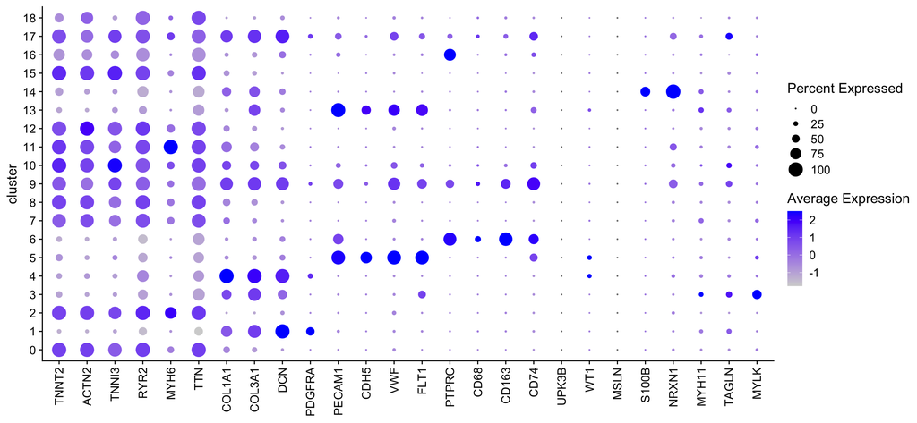

```r
DotPlot(seu, features = genes, assay = "SCT") +
    theme(axis.text.x = element_text(angle = 90, hjust = 1, vjust = 0.5)) +
    labs(x = NULL, y = "cluster")
```

# 2. Naming the clusters

### DECISION 4 — what is your cluster? *(15 min)*

> Your demonstrator will give each pair **one cluster number**.
> 1. Pull its top markers with the chunk below.
> 2. Look them up. [PanglaoDB](https://panglaodb.se/search.html) is a searchable database of cell-type markers; the [Human Protein Atlas](https://www.proteinatlas.org/) is good for single genes.
> 3. **Then go back and check your cluster in the DotPlot above.** `FindAllMarkers` returns what makes your cluster *different from the other eighteen* — which is not the same as what makes it what it is. If eleven clusters are the same cell type, the genes defining that cell type cancel out and never appear in any of their marker lists.
> 4. **Commit to an answer before you look at the reveal.** Write down the cell type *and* your confidence: certain / fairly sure / guessing.

```r
my_cluster <- 5   # <- YOUR CLUSTER NUMBER

markers |>
    filter(cluster == my_cluster) |>
    slice_max(avg_log2FC, n = 15) |>
    select(gene, avg_log2FC, pct.1, pct.2, p_val_adj)
```

|  | gene | avg_log2FC | pct.1 | pct.2 | p_val_adj |
| --- | --- | --- | --- | --- | --- |
| NOTCH4 | NOTCH4 | 6.699410 | 0.749 | 0.019 | 0.000000e+00 |
| BTNL9 | BTNL9 | 6.584191 | 0.728 | 0.026 | 0.000000e+00 |
| NR5A2 | NR5A2 | 6.521185 | 0.467 | 0.016 | 0.000000e+00 |
| CYYR1 | CYYR1 | 6.364194 | 0.906 | 0.045 | 0.000000e+00 |
| CYYR1-AS1 | CYYR1-AS1 | 6.333526 | 0.402 | 0.011 | 0.000000e+00 |
| TPO | TPO | 6.297209 | 0.477 | 0.031 | 0.000000e+00 |
| LINC00639 | LINC00639 | 6.222456 | 0.328 | 0.023 | 1.901440e-207 |
| ADGRL4 | ADGRL4 | 6.165968 | 0.853 | 0.031 | 0.000000e+00 |
| TM4SF18 | TM4SF18 | 6.099528 | 0.296 | 0.006 | 1.960186e-312 |
| CA4 | CA4 | 5.898321 | 0.316 | 0.014 | 5.005809e-253 |

[output cut: 5 more lines]

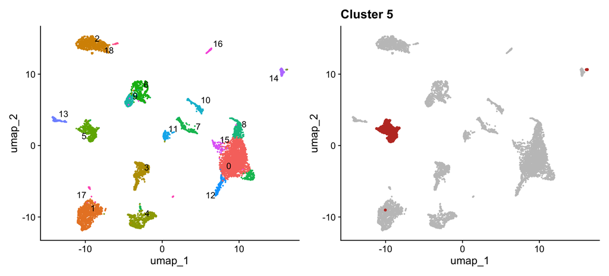

```r
p1 <- DimPlot(seu, reduction = "umap", label = TRUE, repel = TRUE) + NoLegend()
p2 <- DimPlot(seu, reduction = "umap",
              cells.highlight = colnames(seu)[seu$seurat_clusters == my_cluster],
              cols.highlight = "#C0392B") +
    NoLegend() + ggtitle(paste("Cluster", my_cluster))
p1 + p2
```

## 2.1 The reveal

These are the labels from the published Sim et al. analysis.

### “Published” is not “correct”

> These labels are one careful team’s interpretation, produced by people who faced the same choices you just did. In at least two clusters here a marker-based reading is *more specific* than the published label, and in at least one the markers point somewhere the label does not.

> **If your answer disagrees, work out why before assuming you were wrong.**

```r
key <- readRDS(file.path(DATA, "celltype_key.rds"))
tab <- table(cluster = seu$seurat_clusters, published = key[colnames(seu)])

# For your cluster: what did the original authors call these cells?
sort(tab[as.character(my_cluster), ], decreasing = TRUE) |> head(3)
```

```
## Endothelial cells           Neurons    Cardiomyocytes
##               407                 4                 3
```

```r
data.frame(
    cluster   = rownames(tab),
    n         = as.integer(rowSums(tab)),
    published = colnames(tab)[apply(tab, 1, which.max)],
    agreement = paste0(round(100 * apply(tab, 1, max) / rowSums(tab)), "%")
)
```

| cluster | n | published | agreement |
| --- | --- | --- | --- |
| 0 | 1775 | Cardiomyocytes | 100% |
| 1 | 867 | Fibroblast | 99% |
| 2 | 761 | Cardiomyocytes | 99% |
| 3 | 506 | Epicardial cells | 86% |
| 4 | 503 | Fibroblast | 88% |
| 5 | 415 | Endothelial cells | 98% |
| 6 | 346 | Immune cells | 99% |
| 7 | 322 | Cardiomyocytes | 91% |
| 8 | 266 | Cardiomyocytes | 99% |
| 9 | 223 | Cardiomyocytes | 87% |

[output cut: 9 more lines]

**Look at that table as a whole before moving on.** We produced **19 clusters**, and **eleven of them are cardiomyocytes**. That is not a failure — cardiomyocytes genuinely differ across foetal, young and adult hearts, and the algorithm is finding real structure.

**Too coarse.** The published analysis describes **8** cell types. Your 19 clusters recover **6**. Run this:

```r
key_tab <- sort(table(key[colnames(seu)]), decreasing = TRUE)
key_tab
```

```
##
##      Cardiomyocytes          Fibroblast   Endothelial cells    Epicardial cells
##                3934                1317                 554                 525
##        Immune cells             Neurons Smooth muscle cells           Erythroid
##                 459                 122                  62                   9
```

**Smooth muscle cells** (62 nuclei) and **erythroid cells** (9 nuclei) are in your data, and no cluster corresponds to either. Sixty of the 62 smooth muscle nuclei are sitting inside cluster 3 — which is why cluster 3’s agreement with the published labels is the worst:

```r
sm <- names(key)[key == "Smooth muscle cells"]
table(seu$seurat_clusters[colnames(seu) %in% sm])
```

```
##
##  0  1  2  3  4  5  6  7  8  9 10 11 12 13 14 15 16 17 18
##  0  0  0 60  0  0  0  0  1  0  1  0  0  0  0  0  0  0  0
```

So the same analysis simultaneously split one cell type into eleven and merged two others into invisibility. **Nothing in the output flagged either.** Rare populations are the ones most likely to be lost, and — as you saw with the QC thresholds in Practical 1 — also the ones most likely to be filtered away earlier. Both failures point the same direction.

### 🤖 What the agent found here

> Claude Science scored **eleven** canonical categories against its clusters: cardiomyocyte, endothelial, fibroblast, pericyte/SMC, myeloid, lymphoid, mast, neural/glial, epicardial, erythroid, cycling.

> Note what is on that list that is **not** in your six: pericyte/smooth muscle, mast cells, erythroid — and it split immune into myeloid vs lymphoid, which is your clusters 6 and 16.

> It looked for the rare populations *by name*, because it started from a reference panel rather than from the clusters. You started from the clusters and asked what they were.

> **HARD SYNC POINT.** Run this now regardless of where you got to. It applies the reference labels so everyone’s downstream numbers match.

```r
labels <- readRDS(file.path(DATA, "cluster_labels.rds"))
seu$celltype <- unname(labels[as.character(seu$seurat_clusters)])
table(seu$celltype)
```

```
##
##    Cardiomyocytes Endothelial cells  Epicardial cells        Fibroblast
##              4016               542               506              1370
##      Immune cells           Neurons
##               432               116
```

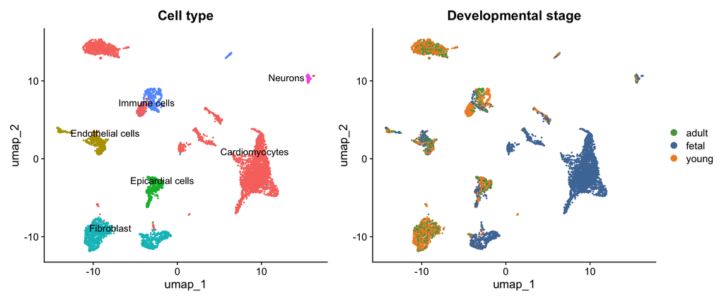

```r
p1 <- DimPlot(seu, reduction = "umap", group.by = "celltype", label = TRUE,
              repel = TRUE) + NoLegend() + ggtitle("Cell type")
p2 <- DimPlot(seu, reduction = "umap", group.by = "group", cols = group_cols,
              shuffle = TRUE) + ggtitle("Developmental stage")
p1 + p2
```

# 3. Does composition change with development?

The first biological question: as the heart matures, do the *proportions* of cell types change?

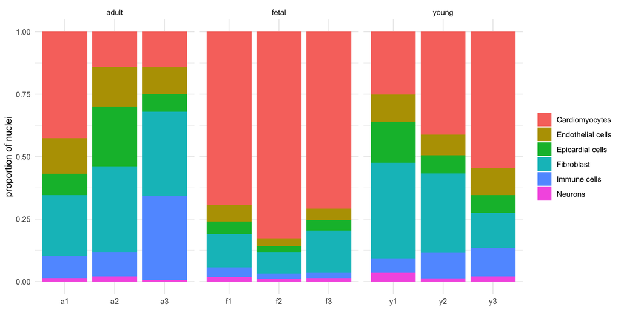

```r
comp <- seu@meta.data |>
    count(sample, group, celltype) |>
    group_by(sample) |>
    mutate(prop = n / sum(n)) |>
    ungroup()

ggplot(comp, aes(sample, prop, fill = celltype)) +
    geom_col() +
    facet_grid(~ group, scales = "free_x", space = "free_x") +
    labs(x = NULL, y = "proportion of nuclei", fill = NULL) +
    theme_minimal()
```

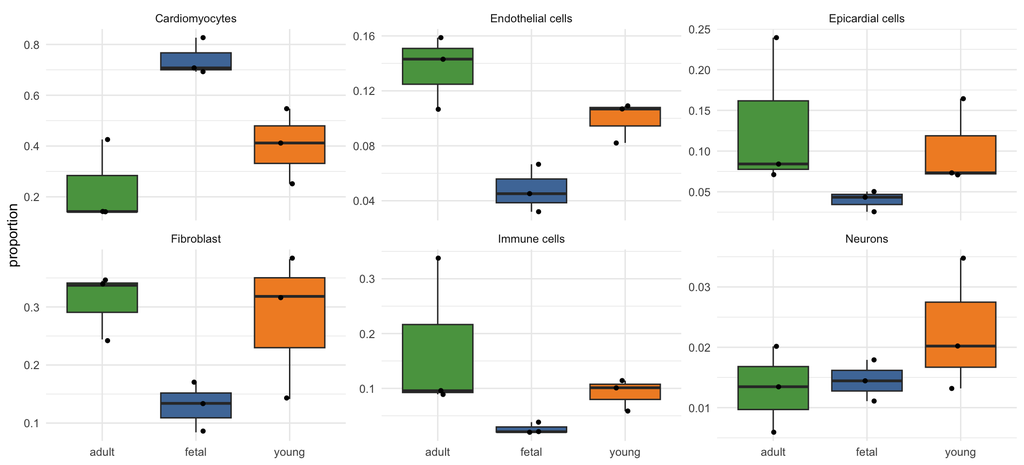

```r
ggplot(comp, aes(group, prop, fill = group)) +
    geom_boxplot(outlier.shape = NA) +
    geom_jitter(width = 0.15, size = 1.2) +
    facet_wrap(~ celltype, scales = "free_y", nrow = 2) +
    scale_fill_manual(values = group_cols) +
    labs(x = NULL, y = "proportion") +
    theme_minimal() + theme(legend.position = "none")
```

We use `propeller` to test if proportions change across developmental stages: it computes each donor’s proportions, transforms them (proportions are bounded and heteroscedastic), and tests across donors.

```r
prop_res <- propeller(clusters = seu$celltype, sample = seu$sample,
                      group = seu$group)
prop_res
```

|  | BaselineProp | PropMean.adult | PropMean.fetal | PropMean.young | Fstatistic | P.Value | FDR |
| --- | --- | --- | --- | --- | --- | --- | --- |
| Cardiomyocytes | 0.57519335 | 0.23633190 | 0.74233704 | 0.40336861 | 15.0437554 | 3.012604e-06 | 1.807562e-05 |
| Immune cells | 0.06187339 | 0.17407386 | 0.02637067 | 0.09120732 | 9.9285632 | 1.448198e-04 | 4.344594e-04 |
| Epicardial cells | 0.07247207 | 0.13149190 | 0.03969544 | 0.10277262 | 4.2963241 | 1.699909e-02 | 2.764171e-02 |
| Endothelial cells | 0.07762819 | 0.13609890 | 0.04787396 | 0.09929943 | 4.1509694 | 1.937997e-02 | 2.764171e-02 |
| Fibroblast | 0.19621885 | 0.30882467 | 0.12924267 | 0.28063415 | 3.9601402 | 2.303476e-02 | 2.764171e-02 |
| Neurons | 0.01661415 | 0.01317877 | 0.01448022 | 0.02271788 | 0.7109563 | 4.943465e-01 | 4.943465e-01 |

This is a strong result even at n = 3 per group. Cardiomyocytes fall from about **74% of nuclei in foetal hearts to 24% in adult**; immune cells and fibroblasts rise correspondingly. Neurons do not change.

One caution: **Compositions are constrained to sum to 1.** If cardiomyocytes fall, then *everything else must rise* whether or not anything happened to it. You cannot read the fibroblast result independently of the cardiomyocyte result.

Recall too from Practical 1 that donor `a3` contributes far fewer nuclei than the others, so its proportions are the noisiest of the nine.

### 🤖 What the agent did here

> **It ran no statistical test of composition at all.**

# 4. Differential expression

Second question: within cardiomyocytes, which genes change between foetal and adult hearts?

## 4.1 The naive approach

Every scRNA-seq tutorial reaches for `FindMarkers()`. Let us run it — but on a **random 100 nuclei per group**, so it finishes in about ten seconds.

```r
cm <- subset(seu, subset = celltype == "Cardiomyocytes" &
                           group %in% c("adult", "fetal"))
table(cm$group, cm$sample)
```

```
##
##           a1   a2   a3   f1   f2   f3
##   adult  253   56   24    0    0    0
##   fetal    0    0    0  812 1268  784
```

```r
set.seed(42) # This is AI's favourite random seed, guess why
cells <- unlist(lapply(c("adult", "fetal"), function(g)
    sample(colnames(cm)[cm$group == g], 100)))
small <- subset(cm, cells = cells)

Idents(small) <- "group"
naive_small <- FindMarkers(small, ident.1 = "adult", ident.2 = "fetal",
                           assay = "SCT", verbose = FALSE)
sum(naive_small$p_val_adj < 0.05)
```

```
## [1] 742
```

Several hundred significant genes, from 200 nuclei.

Now: If we repeat this with all ~3,200 cardiomyocytes instead of 200, what happens to that number?

## 4.2 Why so many false positives

Take two foetal donors. Same developmental stage, same tissue, same protocol. There is no developmental difference between `f1` and `f2`.

These are pre-computed (about four minutes to run), all at the **same 300 cells per side**, so the numbers are directly comparable.

```r
demo <- readRDS(file.path(DATA, "de_demo.rds"))
demo$wilcoxon
```

| comparison | kind | n_sig |
| --- | --- | --- |
| adult vs fetal | real contrast | 2019 |
| f1 vs f2 | same stage (foetal) | 438 |
| f2 vs f3 | same stage (foetal) | 244 |
| f1 vs f3 | same stage (foetal) | 496 |

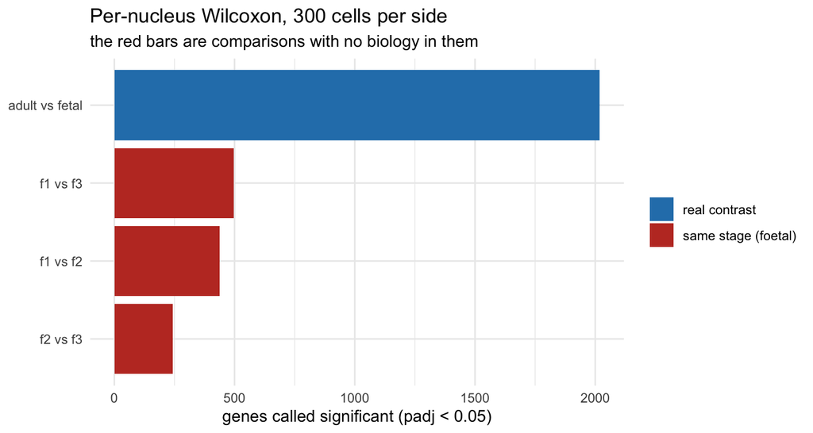

```r
ggplot(demo$wilcoxon, aes(reorder(comparison, n_sig), n_sig, fill = kind)) +
    geom_col() +
    coord_flip() +
    scale_fill_manual(values = c(`real contrast` = "#2980B9",
                                 `same stage (foetal)` = "#C0392B")) +
    labs(x = NULL, y = "genes called significant (padj < 0.05)", fill = NULL,
         title = "Per-nucleus Wilcoxon, 300 cells per side",
         subtitle = "the red bars are comparisons with no biology in them") +
    theme_minimal()
```

## How should we interpret the results?

## 4.3 More defensible approach: pseudobulk

It is generally acceptable to assume that different donors are independent, even within the same condition. Hence we create **pseudo-bulks** from single nuclei.

`Seurat2PB()` **sums the raw counts** across all nuclei of one cell type within one donor. One column per donor × cell type, on the same count scale as a bulk RNA-seq library — so the whole bulk toolkit (edgeR/limma) applies unchanged, and the replicate is now the donor rather than the nucleus.

```r
seu$Celltype <- seu$celltype
seu$Sample   <- seu$sample
DefaultAssay(seu) <- "RNA"

pb <- Seurat2PB(seu, sample = "Sample", cluster = "Celltype")
dim(pb)
```

```
## [1] 18953    54
```

```r
# Cardiomyocytes only
pb_cm <- pb[, pb$samples$cluster == "Cardiomyocytes"]
pb_cm$samples$group <- sub("[0-9]+$", "", pb_cm$samples$sample)
pb_cm$samples$group <- c(a = "adult", f = "fetal", y = "young")[pb_cm$samples$group]
table(pb_cm$samples$group)
```

```
##
## adult fetal young
##     3     3     3
```

Nine columns. That is the real sample size, and it was always the real sample size.

The rest is a classic bulk limma-voom pipeline:

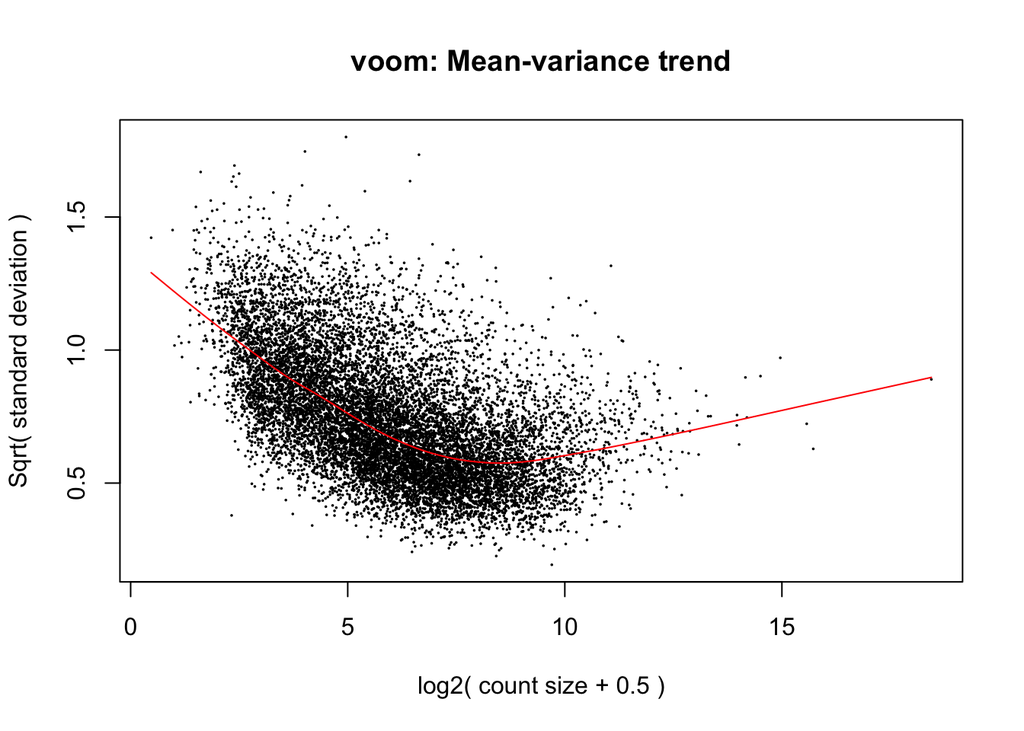

```r
keep <- filterByExpr(pb_cm, group = pb_cm$samples$group)
pb_cm <- pb_cm[keep, , keep.lib.sizes = FALSE]
pb_cm <- normLibSizes(pb_cm)

design <- model.matrix(~ 0 + factor(pb_cm$samples$group))
colnames(design) <- levels(factor(pb_cm$samples$group))

v   <- voom(pb_cm, design, plot = TRUE)
```

```r
fit <- lmFit(v, design)
fit <- contrasts.fit(fit, makeContrasts(adult - fetal, levels = design))
fit <- eBayes(fit)

summary(decideTests(fit))
```

```
##        adult - fetal
## Down             807
## NotSig         10943
## Up               762
```

```r
topTable(fit, n = 15)
```

|  | gene | logFC | AveExpr | t | P.Value | adj.P.Val | B |
| --- | --- | --- | --- | --- | --- | --- | --- |
| TMEM178B | TMEM178B | 6.953298 | 7.163612 | 23.14434 | 5.706254e-10 | 7.139665e-06 | 12.817936 |
| MIR29B2CHG | MIR29B2CHG | 4.017479 | 6.122942 | 20.17365 | 2.175242e-09 | 1.360831e-05 | 11.988143 |
| HECW2 | HECW2 | -5.570241 | 6.480409 | -15.12874 | 3.486801e-08 | 1.090671e-04 | 9.042221 |
| FYB2 | FYB2 | 5.438873 | 4.710807 | 14.55191 | 5.051933e-08 | 1.264196e-04 | 8.924033 |
| CSGALNACT1 | CSGALNACT1 | 3.327867 | 7.293245 | 13.47445 | 1.048509e-07 | 1.535994e-04 | 8.451090 |
| FILIP1L | FILIP1L | 3.503715 | 7.771843 | 13.39147 | 1.111587e-07 | 1.535994e-04 | 8.392192 |
| FAM3D-AS1 | FAM3D-AS1 | 6.129531 | 2.455628 | 16.21773 | 1.791954e-08 | 7.473645e-05 | 8.378458 |
| THRB | THRB | 4.957967 | 7.363638 | 13.34475 | 1.148921e-07 | 1.535994e-04 | 8.358926 |
| CFAP61 | CFAP61 | 4.924364 | 5.478076 | 13.28013 | 1.202836e-07 | 1.535994e-04 | 8.218466 |
| AQP7 | AQP7 | 6.119563 | 5.779724 | 13.25083 | 1.228190e-07 | 1.535994e-04 | 8.166827 |

[output cut: 5 more lines]

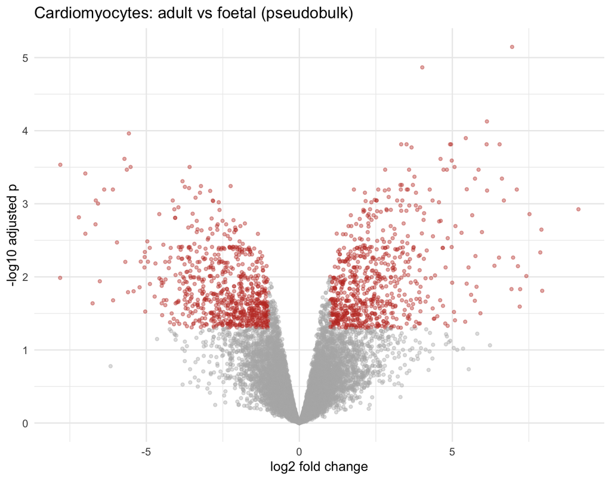

```r
tt <- topTable(fit, n = Inf)
tt$sig <- tt$adj.P.Val < 0.05 & abs(tt$logFC) > 1
ggplot(tt, aes(logFC, -log10(adj.P.Val), colour = sig)) +
    geom_point(alpha = 0.4, size = 1) +
    scale_colour_manual(values = c(`FALSE` = "grey70", `TRUE` = "#C0392B")) +
    labs(title = "Cardiomyocytes: adult vs foetal (pseudobulk)",
         x = "log2 fold change", y = "-log10 adjusted p") +
    theme_minimal() + theme(legend.position = "none")
```

### 🤖 What the agent did here

> Same contrast, same data. It ran **per-cell Wilcoxon** and reported **5,967 significant genes** as its headline result, with a volcano plot.

> Then, in its caveats:

> > *“Wilcoxon on individual cells treats cells as replicates and **inflates significance** — for anything you’d report, redo this as donor-level pseudobulk with DESeq2 at n=3 per stage.”*

> **But it did not do it.** Pseudobulk appears in its output only as a heatmap.